# Class 06: Assignment

John Doll

Feb 12 2020

## Exercise

An experiment was conducted to study the effects of temperature and type of oven on the life of a particular component. Four types of ovens and three temperature levels were used in the experiment. Twenty-four pieces were assigned randomly to each treatment (i.e. each combination of temperature and oven type) in equal sizes of 2 replications, and the data were recorded in `componentCast.csv` on the Hughes data repository.

Describe the following:

- **Experimental Units in this study?**

*The 24 different components*

- **The factors of interest in this study?**

*Temperature and oven type*

- **How many factor levels are there?**

*12, four oven types times 3 temperatures*

- **What are the treatments?**

*oven A, temp 500; oven A, temp 550; oven A, temp 600;* *oven B, temp 500; oven B, temp 550; oven B, temp 600;* *oven C, temp 500; oven C, temp 550; oven C, temp 600;* *oven D, temp 500; oven D, temp 550; oven D, temp 600;*

- **What other steps were taken to control for nuisance variables and unexplained variability?**

*The pieces were randomly assigned to each treatment. The experiment was replicated twice. Each replication was the same size.*

We begin our analysis by briefly looking at the data.

```r
component <- read.csv("http://users.miamioh.edu/hughesmr/sta363/componentCast.csv")
kable(head(component))
```

| Temperature | Oven | Lifetime |
| --- | --- | --- |
| 500 | A | 227 |
| 500 | A | 221 |
| 500 | B | 214 |
| 500 | B | 259 |
| 500 | C | 225 |
| 500 | C | 236 |

**GOAL.** In this study we are interested in testing if the different temperature and/or ovens have an effect on the life of the components.

### Data Cleaning

The first thing we will do is make sure everything is correct in R. We will convert both `Temperature` and `Oven` to factors. `Temperature` is recorded as a numeric variable but we want to treat it categorically here. (We also do this with `Oven`, though it is not necessary.)

```r
# Convert Temperature and Oven to factors
component <- component %>%
  mutate(Temperature = as.factor(Temperature),
         Oven = as.factor(Oven))
glimpse(component)
```

```
## Observations: 24
## Variables: 3
## $ Temperature <fct> 500, 500, 500, 500, 500, 500, 500, 500, 550, 550, 550, 55…
## $ Oven        <fct> A, A, B, B, C, C, D, D, A, A, B, B, C, C, D, D, A, A, B, …
## $ Lifetime    <int> 227, 221, 214, 259, 225, 236, 260, 229, 187, 208, 181, 17…
```

### EDA

Create an interaction plot for temperature and oven type. Put `Temperature` on the *x*-axis since it is naturally quantitative (compared to the oven type (labeled A, B, C, D)), so it follows intuition a little bit better.

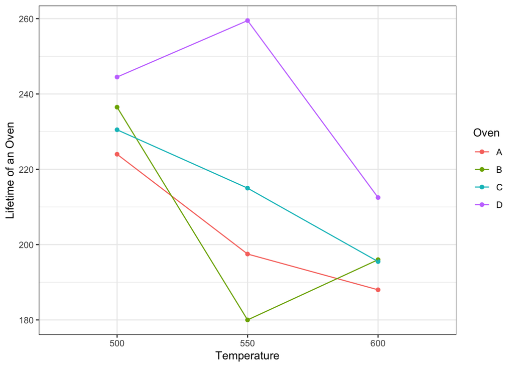

```r
ggplot(component, aes(x = Temperature, y = Lifetime, color = Oven, group = Oven)) +
  stat_summary(fun.y=mean, geom="point") +
  stat_summary(fun.y=mean, geom="line") +
  labs(y="Lifetime of an Oven") +
  theme_bw()
```

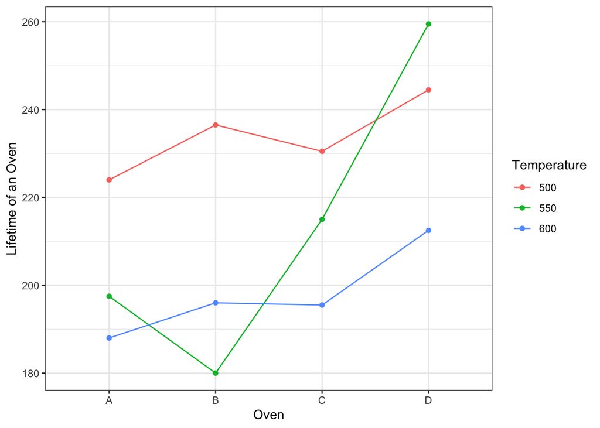

```r
ggplot(component, aes(x = Oven, y = Lifetime, color = Temperature, group = Temperature)) +
  stat_summary(fun.y=mean, geom="point") +
  stat_summary(fun.y=mean, geom="line") +
  labs(y="Lifetime of an Oven") +
  theme_bw()
```

*The oven lifetimes are all very similar for temperature at 500 degrees. At 550 degrees, the lifetimes spread out, with only the lifetime of oven D increasing. At 600 degrees, ovens A, B, C come to around the same value, with oven B increasing. Oven D drops in lifetime by a lot but not to close to the cluster of the other three ovens.*

### Analysis

Perform a Two-Way ANOVA. Be sure to check your assumptions!

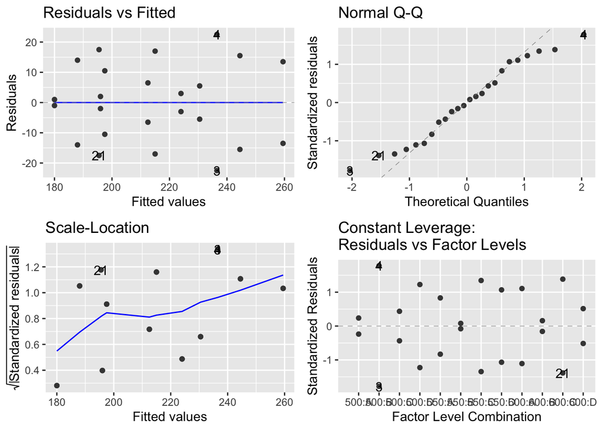

```r
component.anova <- aov(Lifetime ~ Temperature + Oven + Temperature:Oven, data = component)
autoplot(component.anova)
```

```r
summary(component.anova)
```

```
##                  Df Sum Sq Mean Sq F value  Pr(>F)
## Temperature       2   5194  2597.0   8.130 0.00586 **
## Oven              3   4963  1654.4   5.179 0.01589 *
## Temperature:Oven  6   3126   521.0   1.631 0.22152
## Residuals        12   3834   319.5
## ---
## Signif. codes:  0 '***' 0.001 '**' 0.01 '*' 0.05 '.' 0.1 ' ' 1
```

*The plots look reasonable for the most part. There is indication of a possible error in the Scale-Location plot since the line is a bit positive but overall, we’re good.*

### Multiple Comparisons

Test the multiple comparisons (only if necessary). Be sure to account for any interactions present in the data.

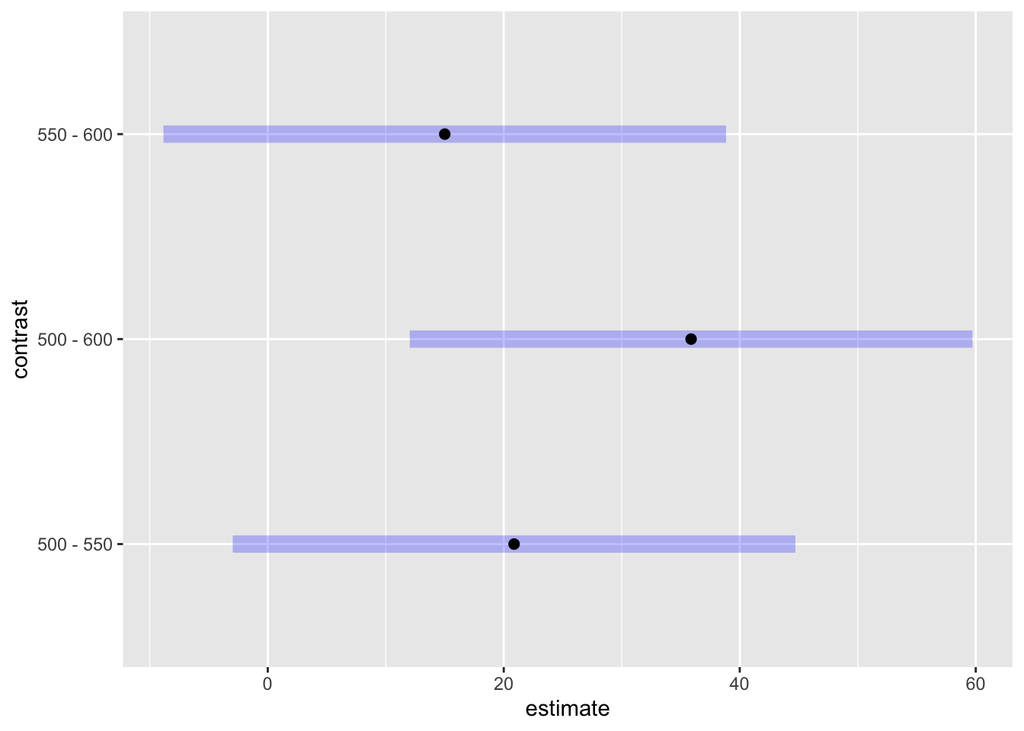

```r
temperature.mc <- emmeans(component.anova, "Temperature")
oven.mc <- emmeans(component.anova, "Oven")
plot(contrast(temperature.mc, "pairwise"))
```

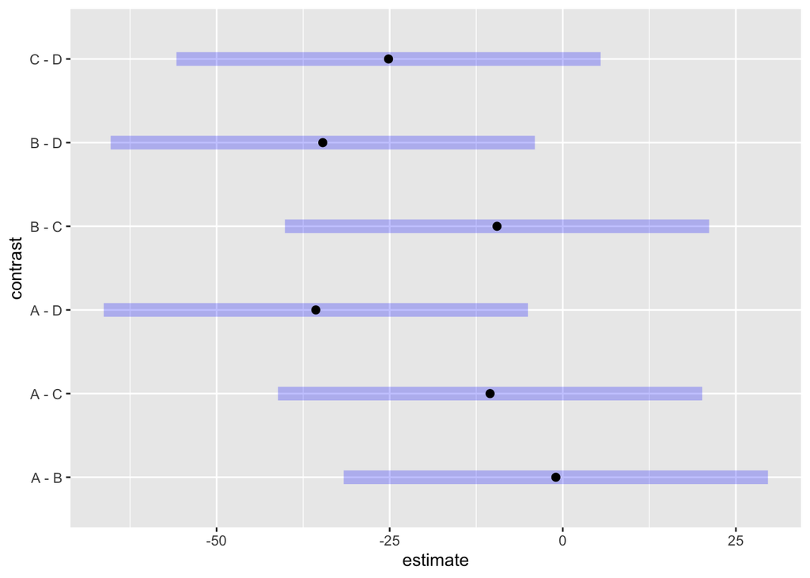

```r
plot(contrast(oven.mc, "pairwise"))
```

*From the temperature plot, we can tell that there is only a significant difference between the ovens at 500 degrees and 600 degrees because 0 is not located within the interval. The difference between the 500 and 550 degree ovens and the difference between the 550 and 600 degree ovens is not significant.* *From the oven plot, we can tell that there is a significant difference between ovens B and D and a significant difference between ovens A and D since 0 is not in either interval. The differences between ovens C and D, B and C, A and C, and A and B are not significant because 0 is in the interval for these observations.*